# 2017 Ecommerce Perú

omar gonzáles díaz

30 de marzo de 2017

# Principales Ecommerce del Perú - Análisis descriptivo

La idea de realizar esta investigación fue conocer las estrategias de los principales ecommerece peruanos basados en los productos que ofrecen en sus respectivos sitios web.

Como menciona el título, esta es una investigación descriptiva. Lo que queremos es mostrar los datos que encontramos e inferir algunos comentarios que se pueden observar. No es el objetivo de esta entrada analizar a profundidad el por qué de cada una de las estrategias de marketing de cada empresa; por el contrario, mencionaremos algunos datos resaltantes que se observan al tener la información de empresas de un mismos sector, que a su vez son competencias entre sí.

[Linio](https://www.linio.com.pe/c/tv-y-video/televisores)

[Falabella](http://www.falabella.com.pe/falabella-pe/category/cat1450502/Smart-TV?navAction=push)

[Ripley](http://www.ripley.com.pe/ripley-peru/tv-todas)

## TVs por Ecommerce

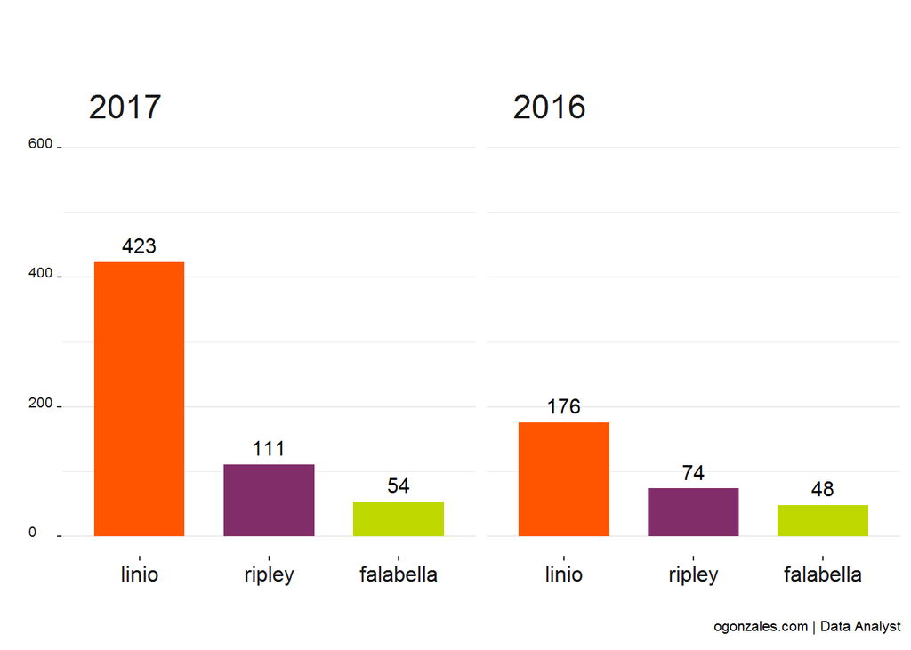

## TVs por Rango de Precio

[interactive chart not shown]

## Distribución de precios por ecommerce

[interactive chart not shown]

## Variedad de marcas de TV según rango de precios

### Ripley

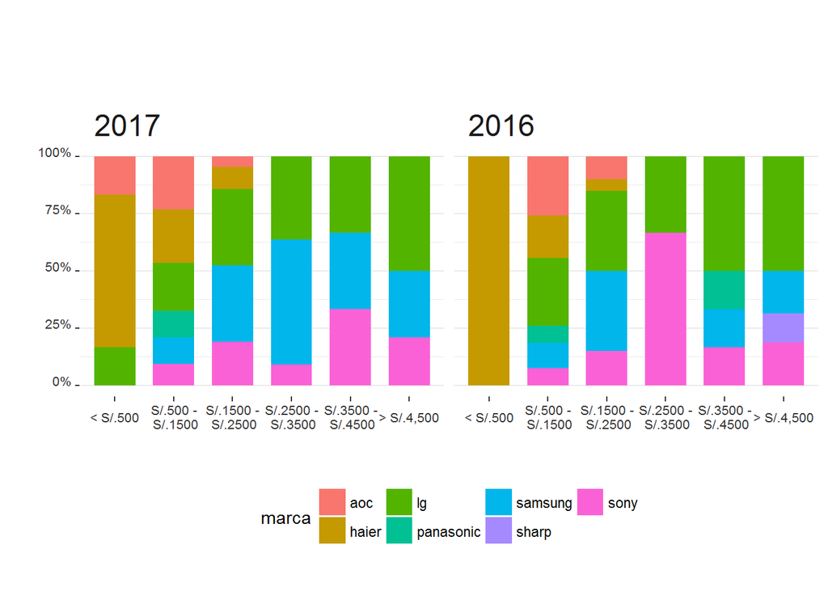

### Falabella

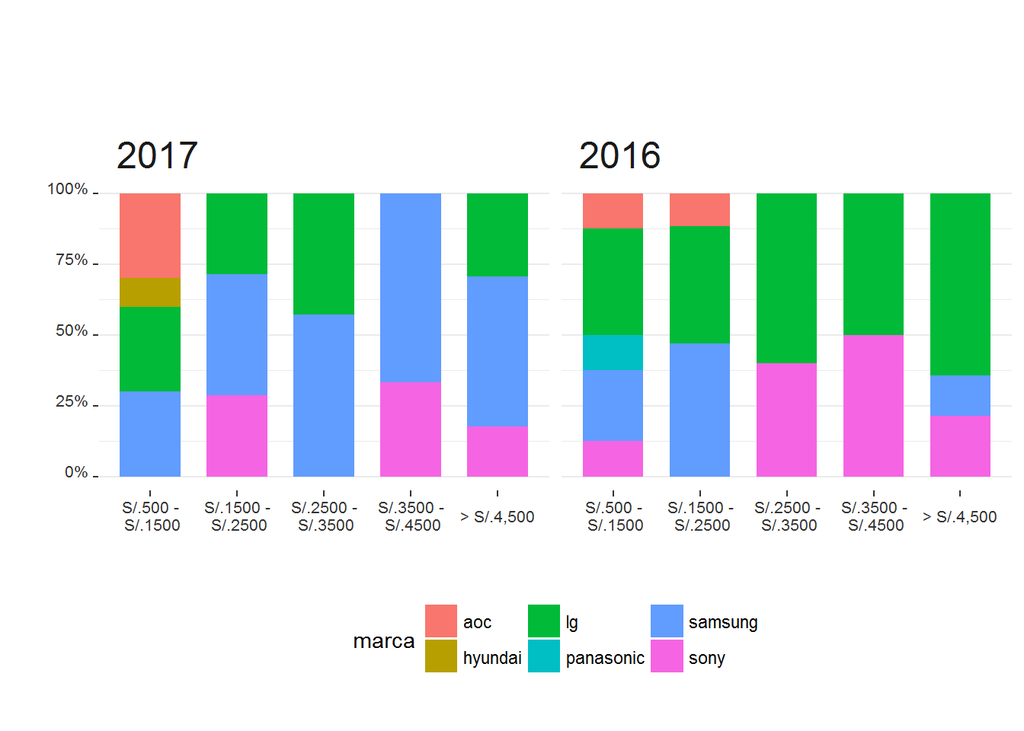

### Linio

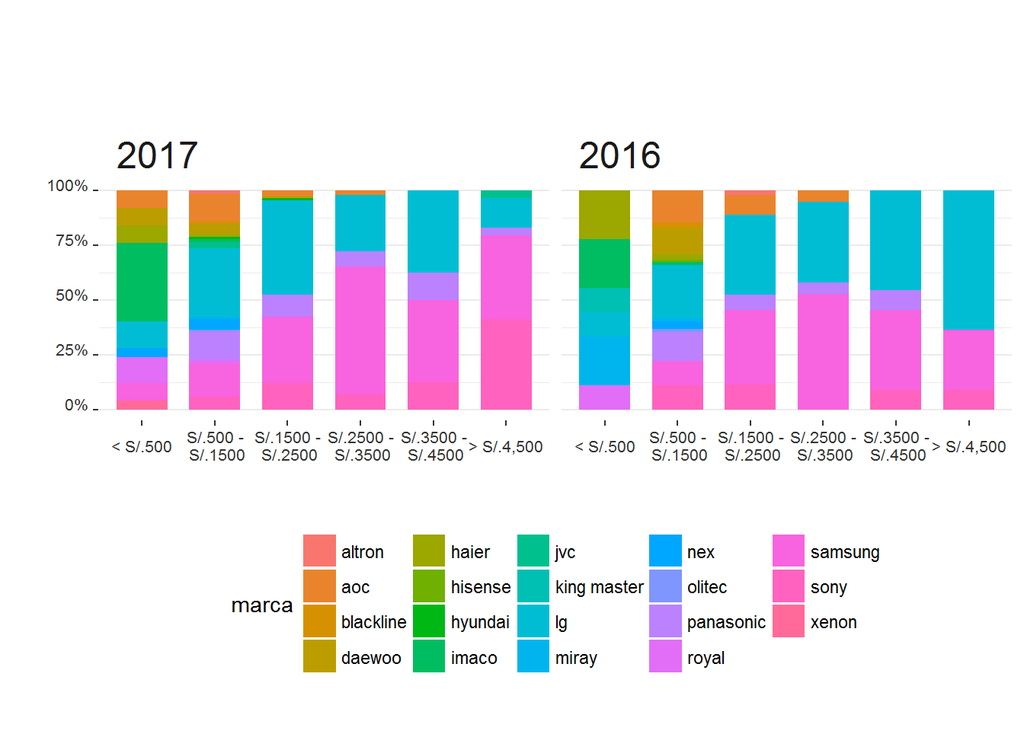

## Precio actual por marca de TV

### Ripley: distribución de precios por marca

[interactive chart not shown]

### Falabella: distribución de precios por marca

[interactive chart not shown]

### Linio: distribución de precios por marca (parte 1 y 2)

[interactive chart not shown]

## Pulgadas vs Precio

Scaterplot que muestra la tendencia entre pulgadas vs precio.

[interactive chart not shown]